# Innovation partnerships for development along green value chains

Innovation partnerships for  
development alonggreen value chains

Samuel Edet, Ralf Martin, Golvine de Rochambeau,  
Trang Thu Tran, Dennis Verhoeven

[figure not shown]

UCL seminar — October 2026

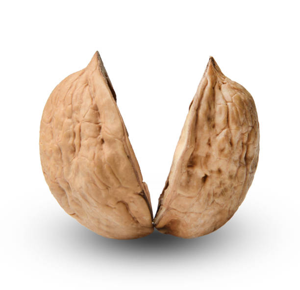

The argument  
in a nutshell

- New technology waves are great growth opportunities (Japan, Korea, Taiwan, India, China)
- **Is the green transition a growth opportunity?** But for whom? Certainly China. Anybody else?
- **A strategy to seize the value in value chains is to seize the Knowledge-Economy Value Chain** (IP, branding; Baldwin & Ito 2021)
- EMDE are doing relatively well in green-tech innovation. (How) could they do more?
- **Most high-quality innovations in EMDE are with HIC partners** (often big MNEs): nearly half (46.5%) of EMDE innovations are cross-group collaborations
- **However, as a group top R&D firms only spend a small fraction of their R&D in EMDE** (2.2% of innovations on average)
- **They could do more: knowledge-spillover benefits for both HIC and EMDE** (inverted U, peak at a 37–44% EMDE share)
- **Self-interested HIC governments could/should incentivise more HIC–EMDE collaborative R&D** — one SD more EMDE share ≈ +$1.8M spillover per innovation to HICs
- **Then again: MNE R&D labs are brain suckers** (net drain, especially in software)

## Data

- **PATSTAT 2025** — last available 10 years: 2013–2022, 6.8 million innovations (patent families), inventors located via address records
- **EU R&D Scoreboard (JRC)** — 6,300 top R&D investors, 5,460 matched to PATSTAT, 4,474 with innovations in the window
- **LinkedIn career histories (Revelio)** — 4,816 Scoreboard firms with usable employee records; 2,162 HIC-headquartered firms in the talent-flow regressions
- **EMDERLT** — hand-verified R&D lab locations of these firms in EMDE (≈1,950 lab–country records, 46 host countries)

[figure not shown]

[figure not shown]

The paper: [CEP Discussion Paper No. 2223](https://cep.lse.ac.uk/pubs/download/dp2223.pdf), October 2026

[figure not shown]

[figure not shown]

IFC report *Innovation in Green Technologies*

## Green Innovation Trends

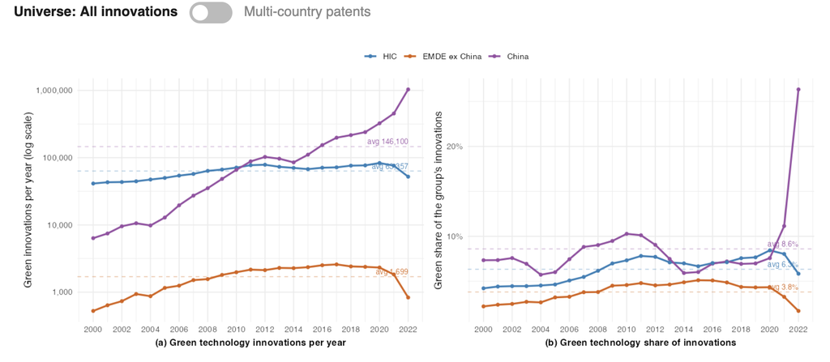

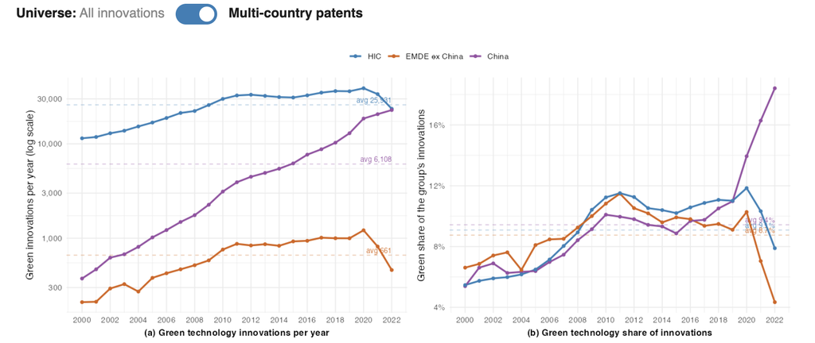

[figure not shown]

From new tool: Green Innovation Dashboard (GID)

EMDE dominate in early years

## The quality of innovation in EMDE

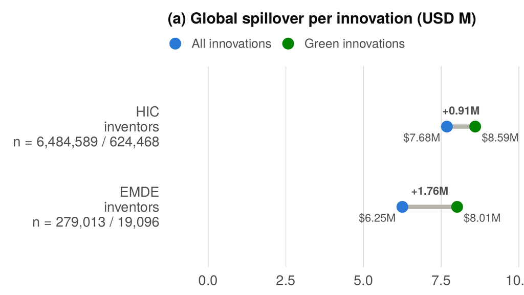

EMDE = Emerging & Developing Economies (World Bank classification, incl. China)

**1. Green generates more value.** Green innovations create more knowledge spillover than the average innovation: **+$0.9M** per innovation for HIC inventors (+12%) and **+$1.8M** for EMDE inventors (+28%)

**2. Green EMDE innovations are as good as the average innovation anywhere:** $8.0M of global spillover vs $7.6M for the average of all 6.8M innovations (HIC average: $7.7M)

## Patent Rank (from Page to Patent Rank)

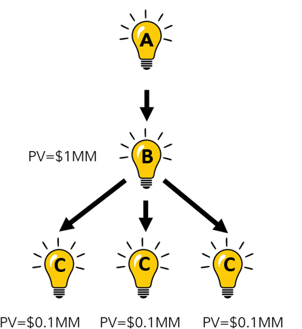

**Page**Rank:

$PageRank_i = \alpha\frac{1}{\#(Webpages)} + \sum_{j\in B(i)} \phi_{ij}\,PageRank_j$

**Patent**Rank:

$PRANK_i = PrivateValue_i + \sum_{j\in B(i)} \phi_{ij}\,PRANK_j$

where $\;\phi_{ij} = \sigma\times\dfrac{1}{\text{Backward cites of } j}$

**Social** value of innovation *i*

**Private** value of innovation *i*: stock-market reaction to the patent grant (Kogan et al. 2017), extended to all patent offices (Guillard et al. 2021)

Contribution of innovation *i* to the value of innovation *j*

Assumptions:  
• all backward cites have the same contribution  
• contribution smaller if a patent cites many

## Making citation counts coherent…

Citations of patent *i* = citing patent 1 + citing patent 2 + …

We need to account for value heterogeneity of patents

Patent Rank fixes both: each citation is weighted by the (social) value of the citing patent and diluted by the number of its backward citations. Private values from Kogan et al. (2017) stock-market reactions, extended to all patent offices (Guillard et al. 2021).

## National vs Global Spillover

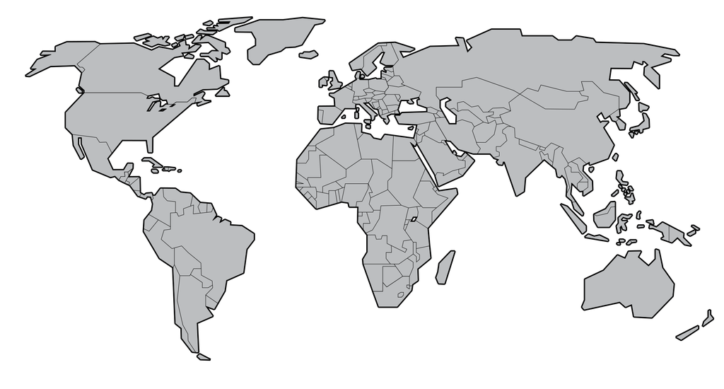

Knowledge also flows the other way – and on to third countries (indirect citations)

The Patent-Rank recursion can be run on **all** citations (global spillover) or only on citations from a given country’s inventors (national spillover, e.g. value accruing to EMDE inventors)

## National vs Global

**A**

↓

PV = $1MM✕

↙ ↓ ↘

PV=$0.1MM

PV=$0.1MM✕

PV=$0.1MM

We can also examine flows of knowledge between countries; e.g. how a non-Belgian innovation contributed to Belgium.

**National Patent Rank:** only the citations (direct and indirect) that come from Belgian inventors count towards the value of A.

## Flows of knowledge

Indirect and direct

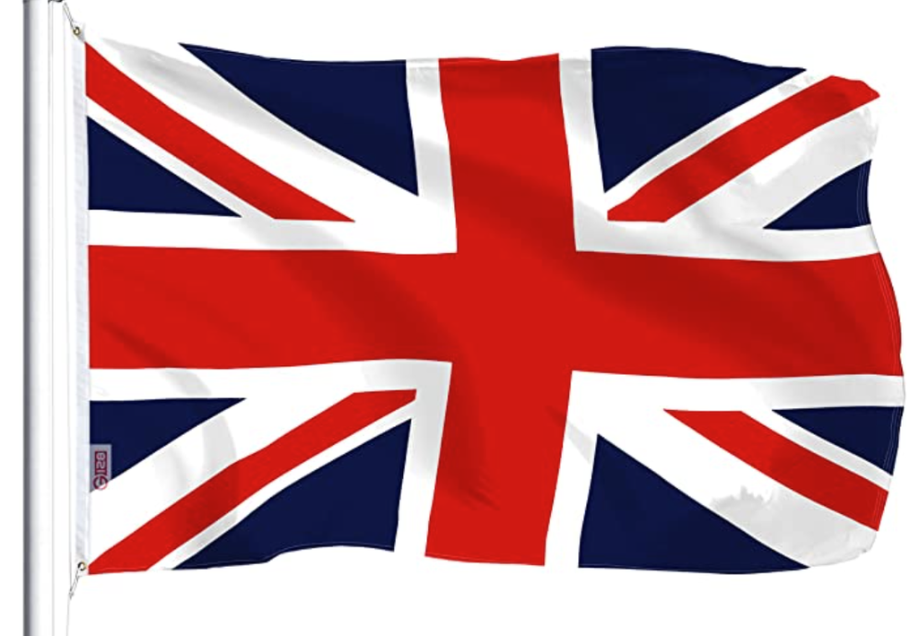

Contributions by UK innovators to the national Belgian Patent Rank

Summing the national Patent Rank of country *d* over innovations made by inventors in country *o* gives the knowledge flow *o* → *d*. This is what we use to split spillovers into “to HIC”, “to EMDE” and “global”.

## Inferring R&D costs

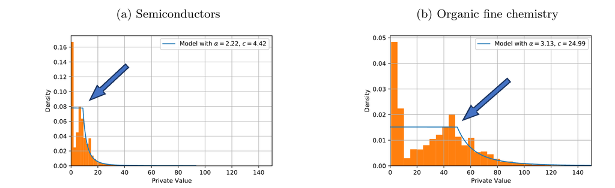

[figure not shown]

Based on [Guillard et al. (2021) ↗](https://cep.lse.ac.uk/_NEW/publications/abstract.asp?index=8614): the observed distribution of private values (orange) is fitted with a model in which ideas are only pursued if their expected value exceeds the R&D cost of the technology area

[figure not shown]

**f(cost):** the hurdle an idea must clear – its height is the R&D cost *c<sub>A</sub>* we infer

We still observe low-value innovations because what looked good *before* the R&D could turn out bad – the mass below *c<sub>A</sub>* is what pins down the cost

## ISTRAX: the spillover return of additional R&D

- Innovators will implement projects below the current profitability constraint
- The additional private net benefit will be (approximately) 0
- Benefit will come from spillovers
- What we need to look at is the spillover below the implementation threshold

$ISTRAX_A = \dfrac{\alpha+1}{cost_A}\sum_{i\in A} EV_i \times I\{PV_i < 2\,cost_A\}$

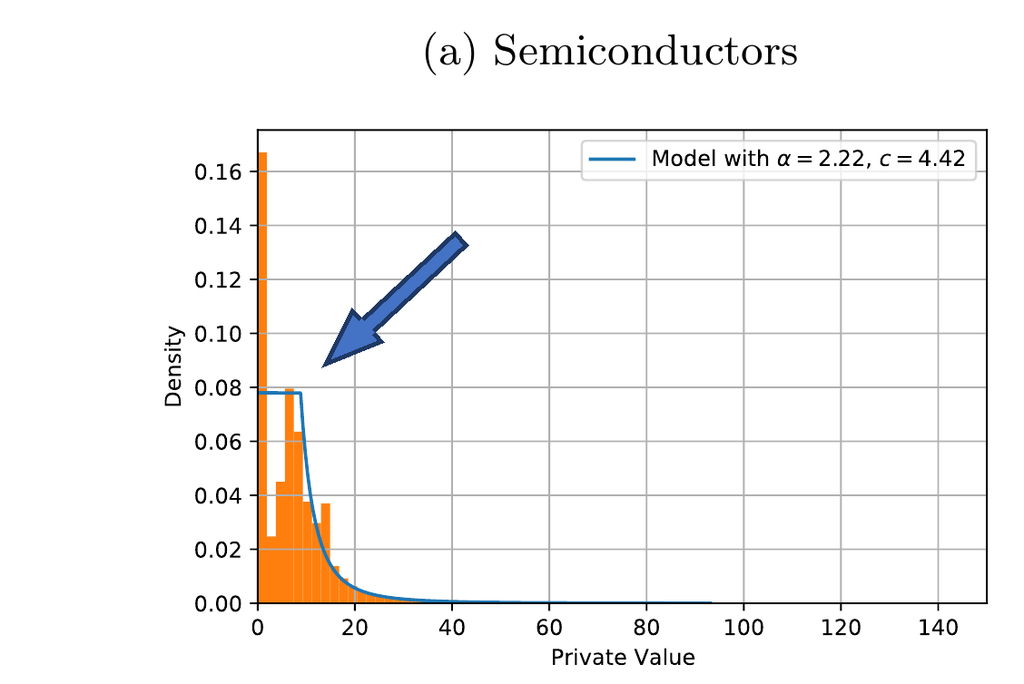

Curvature of idea-generation function

Tech area

Prank external value

From Kogan et al.

## Should there be more? Marginal social return

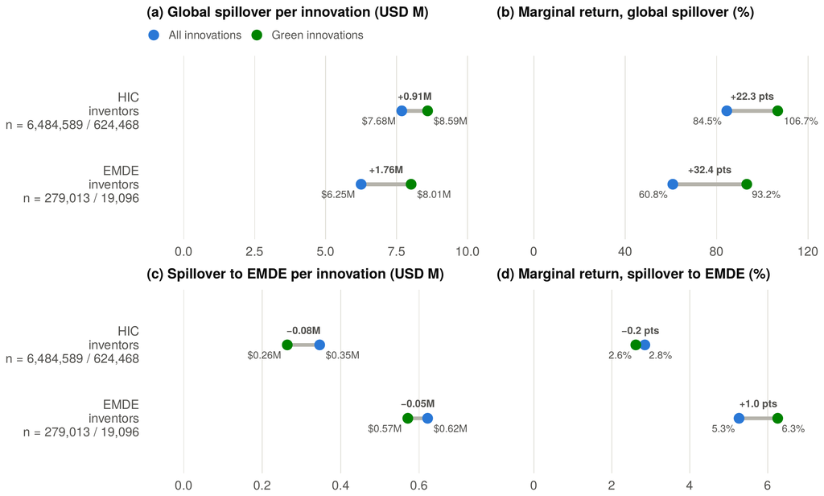

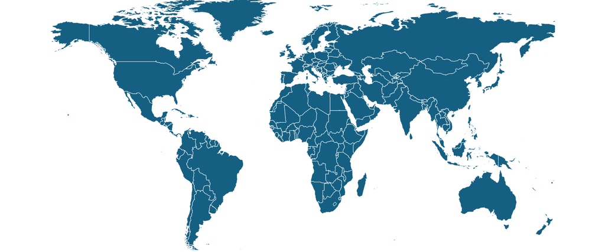

**Global:** received anywhere

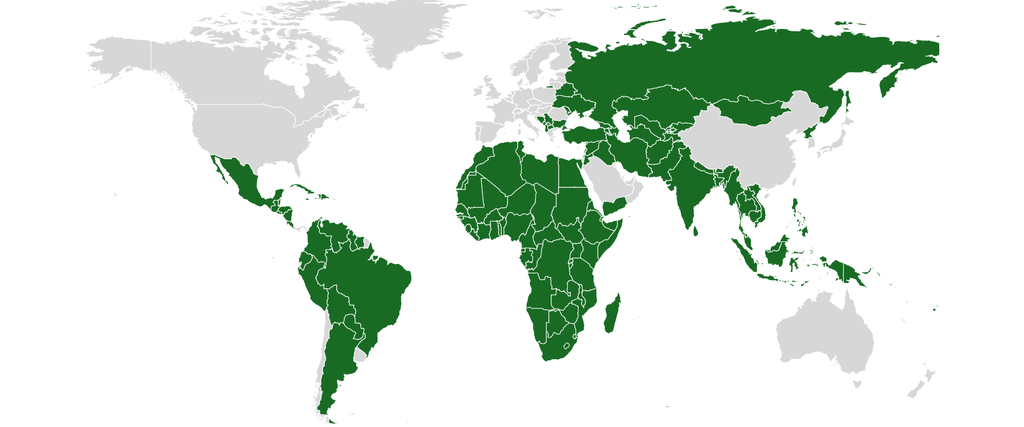

**To EMDE** (excl. China)

$

%

$

%

**$1M in additional R&D by HIC inventors = $1.85M** in internal and external return (all innovations) — **$2.07M for green**

Shifting to green makes sense even if you don’t care about climate change …

… even for EMDE innovators when considering EMDE benefits only. But who can/would/should/could pay for it?

## Who is driving EMDE innovation?

i.e. who is paying already?

EMDE–HIC collaboration With Chinese inventor Same income group National only

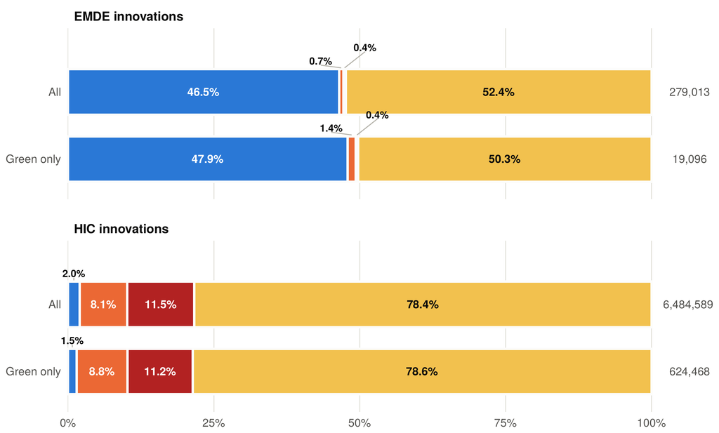

**Nearly half (46.5%) of EMDE innovations** are collaborations with HIC inventors (47.9% for green)

**The view from HIC:** EMDE inventors appear in only **2.0%** of HIC innovations (1.5% green); non-HIC partners are mostly Chinese (8.1%), 78% are purely national

## Returns to EMDE innovations by type of collaboration

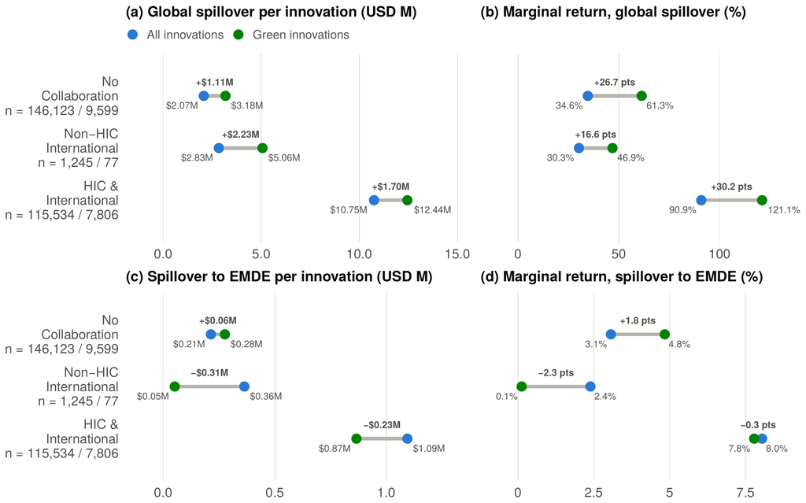

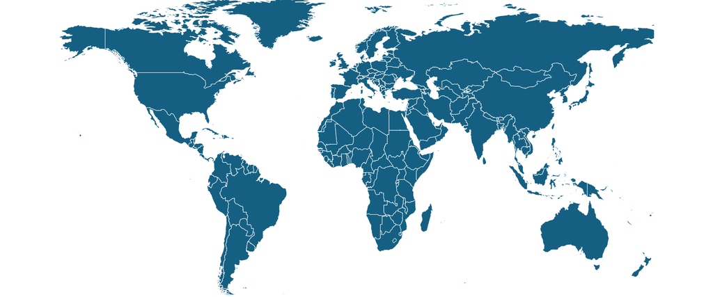

**Global:** received anywhere

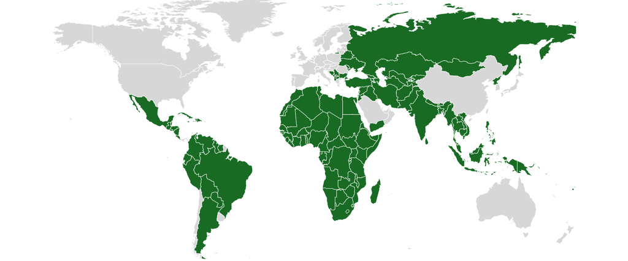

**To EMDE** (excl. China)

$

%

$

%

**HIC–international collaborations** generate $10.8M of global spillover per innovation and a **91% marginal return** (121% for green) …

… versus $2.1M and 35% (61% green) for innovations without international collaboration

Spillovers *to EMDE* are also highest for HIC collaborations ($0.9–1.1M per innovation)

No big brain robbery!

## R&D Scoreboard firms

- Top ~2,000–2,500 R&D spenders every year since 2003: **6,339 names, 6,300 distinct firms** in total
- New match with PATSTAT 2025: **5,460 matched; 4,474 with innovations in 2013–2022** (4,286 in the regressions)
  - Harmonising PATSTAT assignee names
- Key variables:
  - **Share of innovations with an EMDE inventor** (mean 2.2%, SD 10.1%; 77% of firms at zero)
  - Controls: R&D per innovation, cost of innovation step, private value, portfolio size, number of inventor countries

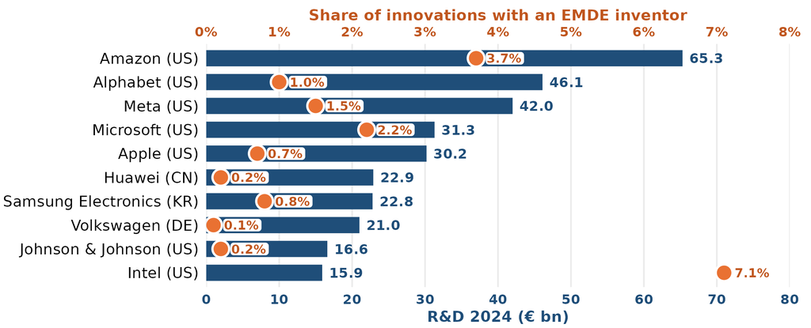

Top 10 by R&D in the 2025 EU Industrial R&D Investment Scoreboard (FY 2024); EMDE share computed over the firm’s 2013–2022 innovations (EMDE excl. China).

[figure not shown]

Diversity of innovation

## Half of HIC cooperations involve the top R&D firms

No collaboration Non-HIC international HIC & international

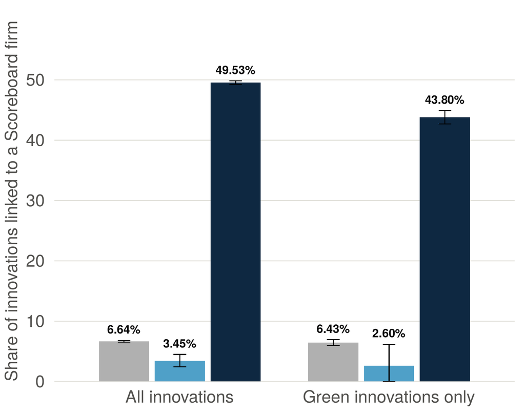

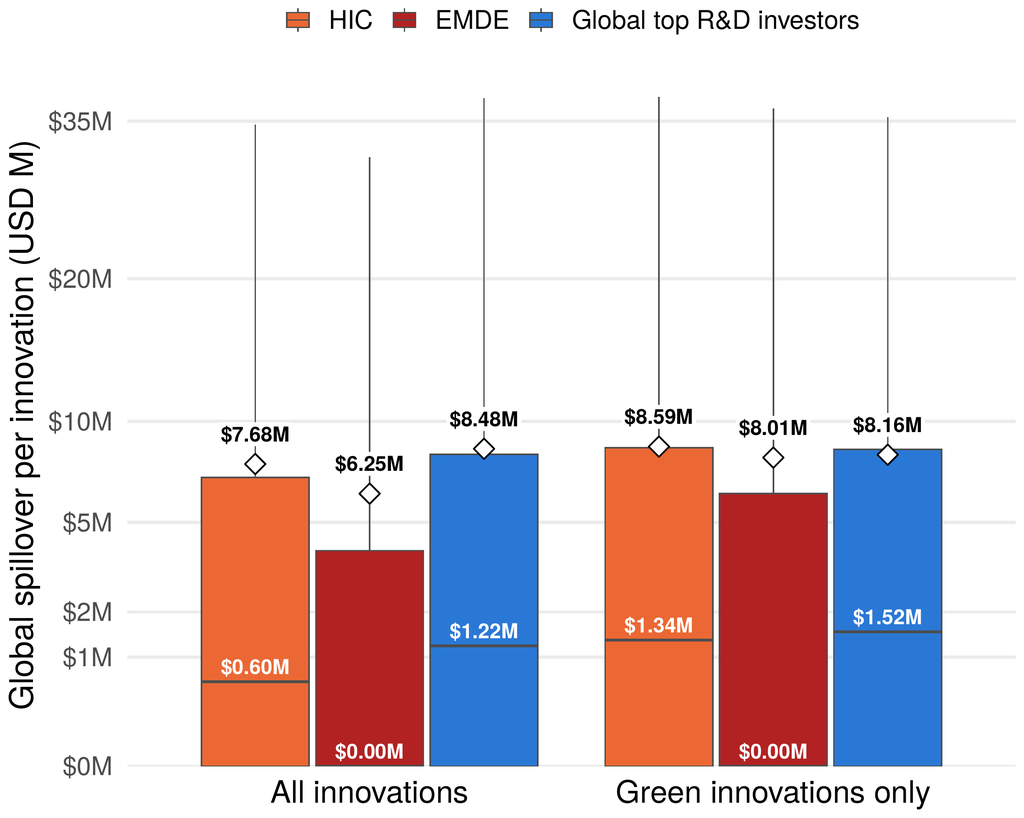

**49.5%** of HIC–EMDE collaborative innovations involve a Scoreboard firm (43.8% green)

• Top ~6,000 firms responsible for a large share of top EMDE R&D • Collectively they do little of their total R&D in EMDE (Figure 4 of the paper)

## Should they do more?

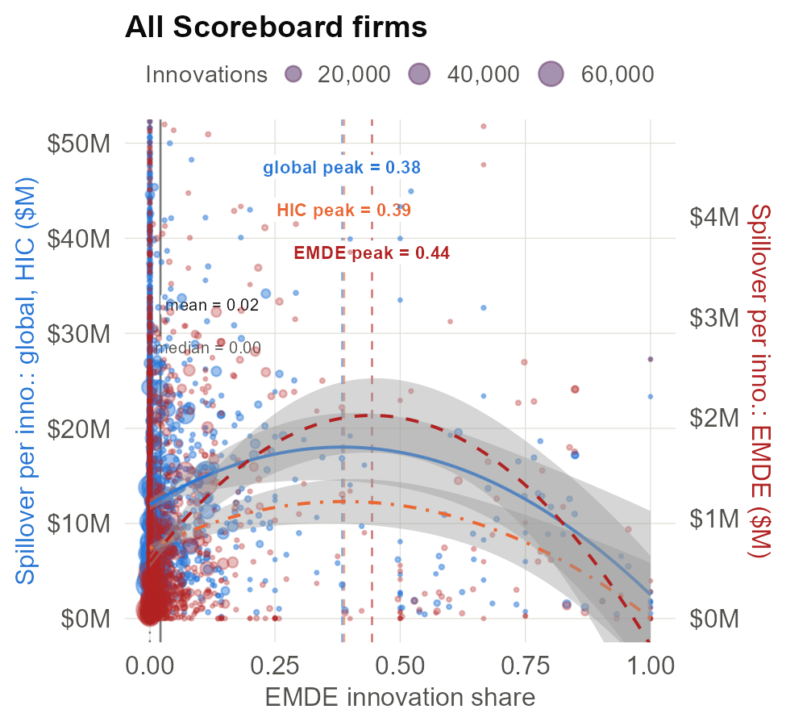

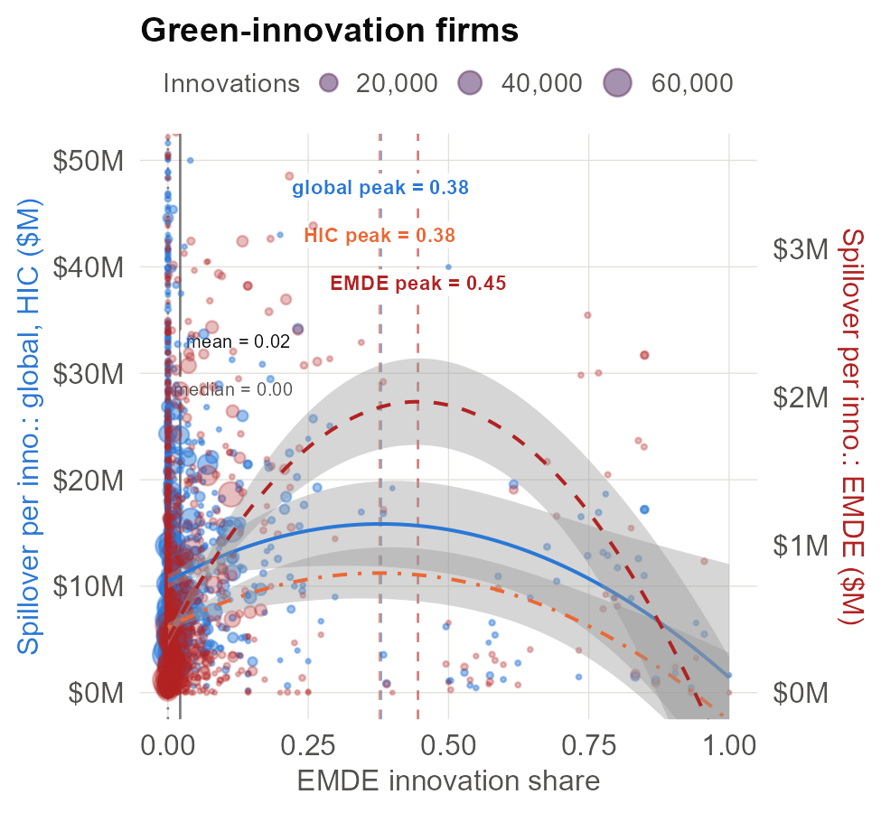

2.2% average

Spillovers increase over a wide range with more EMDE–HIC diversity: peaks at 0.38 (global), 0.39 (HIC), 0.44 (EMDE)

Both HIC and EMDE gain

## Simple regression model

$Av.\,Spillover_i = \beta_1\,EMDEShare_i + \beta_2\,EMDEShare_i^2 + X_i\gamma + \epsilon_i$

R&D per innovation, cost of the innovation step, private value, log portfolio size, number of inventor countries

- Firm-level cross-section of the 4,286 Scoreboard firms with innovations in 2013–2022 (2,611 green-innovation firms)
- Outcomes: spillover per innovation to EMDE, globally and to HIC
- Peak of the inverted U at $-\beta_1/2\beta_2$
- Robustness (appendix): binned estimates, EMDE-inventor share instead of innovation share, HIC-HQ firms, ≥10 innovations, sector FE, pre-2019 patents only

## Robustness of the **∩**

| Per innovation (USD M) Sample | to EMDE All (1) | Global All (2) | to HIC All (3) | to EMDE Green (4) | Global Green (5) | to HIC Green (6) |
| --- | --- | --- | --- | --- | --- | --- |
| EMDE innovation share | 6.044*** | 28.205*** | 21.538*** | 6.037*** | 14.827 | 15.848*** |
|  | (0.865) | (8.495) | (5.565) | (0.735) | (10.212) | (6.103) |
| (EMDE innovation share)² | −6.875*** | −38.982*** | −28.964*** | −6.640*** | −21.391 | −21.465*** |
|  | (1.101) | (10.820) | (7.088) | (0.974) | (13.535) | (8.088) |
| Number of inventor countries | 0.009* | 0.086* | 0.102*** | 0.006** | 0.098** | 0.107*** |
|  | (0.005) | (0.045) | (0.029) | (0.003) | (0.042) | (0.025) |
| log(Number of innovations, 100s) | −0.089*** | −0.911*** | −0.771*** | −0.040** | −1.055*** | −0.776*** |
|  | (0.020) | (0.201) | (0.131) | (0.017) | (0.233) | (0.139) |
| log(R&D per innovation) | 0.030 | 0.746*** | 0.258** | 0.050*** | 0.899*** | 0.345** |
|  | (0.020) | (0.195) | (0.128) | (0.017) | (0.230) | (0.137) |
| R&D missing | −0.003 | −0.771 | −0.655 | −0.082 | −1.616 | −0.768 |
|  | (0.128) | (1.255) | (0.822) | (0.099) | (1.375) | (0.822) |
| log(Cost of innovation step) | 0.432*** | 5.394*** | 3.242*** | 0.353*** | 5.559*** | 2.689*** |
|  | (0.050) | (0.492) | (0.322) | (0.047) | (0.659) | (0.394) |
| Private value (USD M / inno) | 0.004*** | 0.027** | 0.042*** | 0.002* | 0.016 | 0.048*** |
|  | (0.001) | (0.012) | (0.008) | (0.001) | (0.018) | (0.011) |
| Peak EMDE share (−β₁/2β₂) | 0.44 | 0.36 | 0.37 | 0.45 | 0.35 | 0.37 |
| Observations | 4,286 | 4,286 | 4,286 | 2,611 | 2,611 | 2,611 |
| R² | 0.058 | 0.073 | 0.080 | 0.095 | 0.087 | 0.103 |

[figure not shown]

A thought experiment

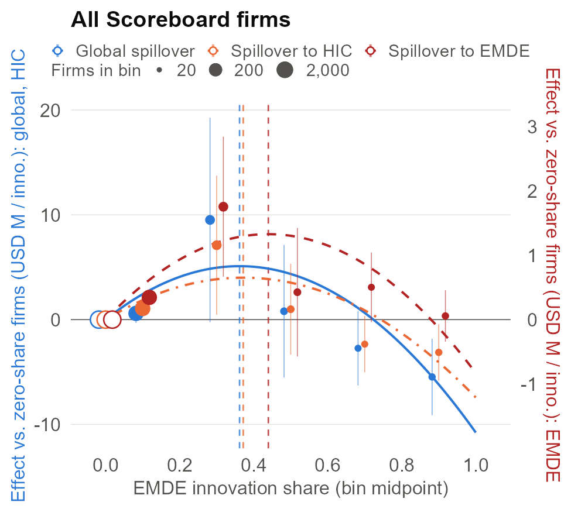

What if a firm moves one standard deviation up: from the sample mean of 2.2% EMDE share to 12.3%?

HIC spillover ↑ **$1.8 million** per innovation  
EMDE spillover ↑ **$0.5 million**  
($2.3 million globally)

Moving all the way to the HIC apex (≈37%) would add about $3.5 million per innovation to HICs and $1.2 million to EMDEs. Even the modest one-SD move implies that HIC governments could, in a purely self-interested way, subsidise diversification by several million dollars per innovation — e.g. via a tax credit along the lines of Isaac & Attridge (CGD, 2025).